# MaltaVAR

Vincent C.| Aditya G.| Georges I.| Filipp K.

5/28/2019

```r
doCheck<-function(name){
  if (!require(name, character.only = TRUE)) {
        install.packages(name)
        library(name, character.only = TRUE)
    }
}
#doCheck("tidyverse")
doCheck("fImport")
doCheck("fOptions")
doCheck("nlstools")
doCheck("tseries")
doCheck("Quandl")
doCheck("zoo")
doCheck("PerformanceAnalytics")
doCheck("quantmod")
doCheck("car")
doCheck("FinTS")
doCheck("fOptions")
doCheck("forecast")
doCheck("stats")
doCheck("vars")
doCheck("tseries")
doCheck("forecast")
doCheck("XML")
doCheck("fBasics")
doCheck("timsac")
doCheck("TTR")
doCheck("lattice")
doCheck("foreign")
doCheck("MASS")
doCheck("stats4")
doCheck("KernSmooth")
doCheck("fastICA")
doCheck("cluster")
doCheck("leaps")
doCheck("mgcv")
doCheck("rpart")
doCheck("datasets")
doCheck("graphics")
doCheck("RColorBrewer")
doCheck("dynlm")
doCheck("readxl")
doCheck("lubridate")
doCheck("fpp2")
doCheck("seasonal")
doCheck("strucchange")
doCheck("astsa")
doCheck("vars")
doCheck("lmtest")
doCheck("dlnm")
doCheck("VAR.etp")

knitr::opts_chunk$set(echo = TRUE)
```

## Introduction

Historically the European bloc has excelled in labor and capital mobility. Thus making the acquistion of any EU passport quite attractive. As a result there has developed a market where non-EU citizens can essentialy purchase a EU-citizenship through investments in small countries like Malta. A coursory search of the internet returns hundreds of agencies with the specific purpose of helping you obtain EU citizenship. In this paper we will investigate the connection between house prices in Malta and the EU GDP. Given that EU GDP increases we would predict that the attractiveness of a EU passport would increase and therefore the housing prices in Malta would also increase.

### Data Initialization

```r
MaltaHPI <- read.csv("MaltaHPI.csv")
EUGDP <- read.csv("CPMNACSCAB1GQEU28.csv")
names(MaltaHPI) <- c("Time", "HPI")
names(EUGDP) <- c("Time", "EUGDP")

#subset data to remove bottom rows
MaltaHPI <- MaltaHPI[-c(57:60),]

#Convert to numeric
MaltaHPI <- transform(MaltaHPI, HPI = as.numeric(HPI))
HPIts <- ts(MaltaHPI$HPI, start=c(2005,1),freq=4)
EUGDPts <- ts(EUGDP$EUGDP, start=c(2005,1),freq=4)
```

## Malta HPI Dataset Analysis

### Timeseries visualization

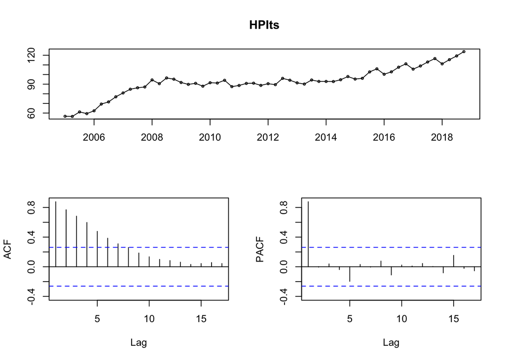

```r
tsdisplay(HPIts)
```

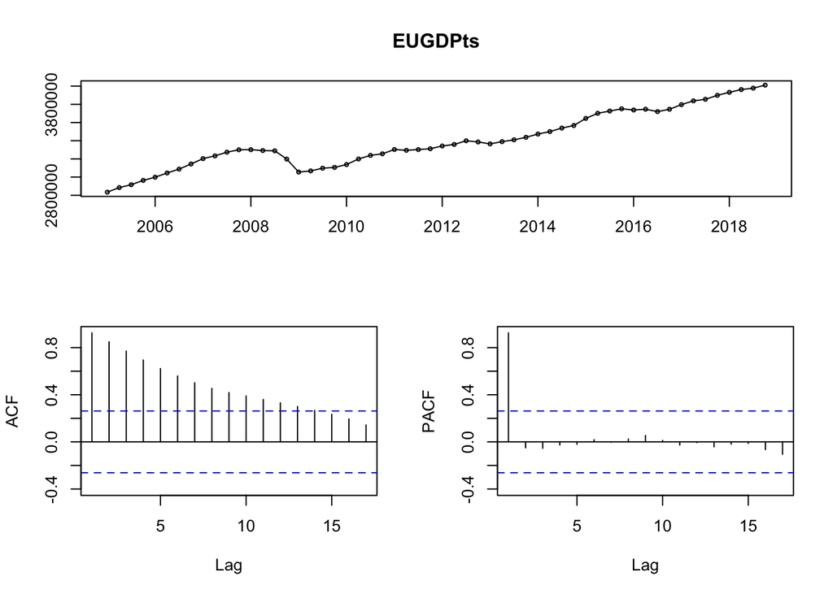

```r
tsdisplay(EUGDPts)
```

Analysis of the correlograms suggests that the series follows an AR-1 process

### Model building

##### House Price Index

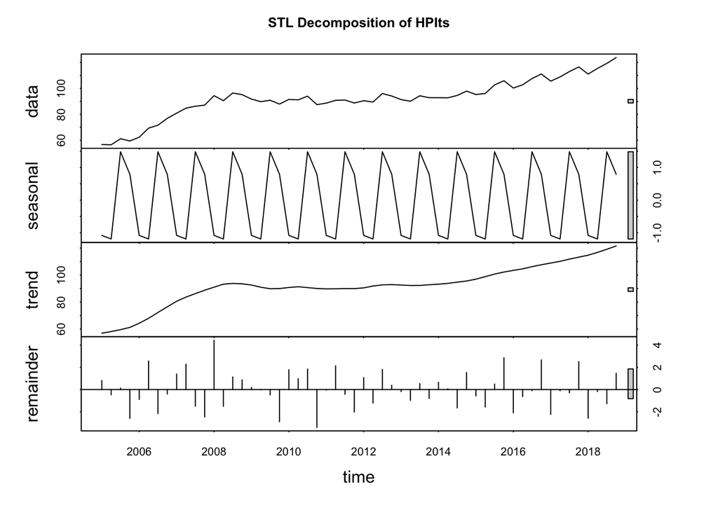

```r
stlHPI=stl(HPIts,s.window = "periodic")
plot(stlHPI,main="STL Decomposition of HPIts")
```

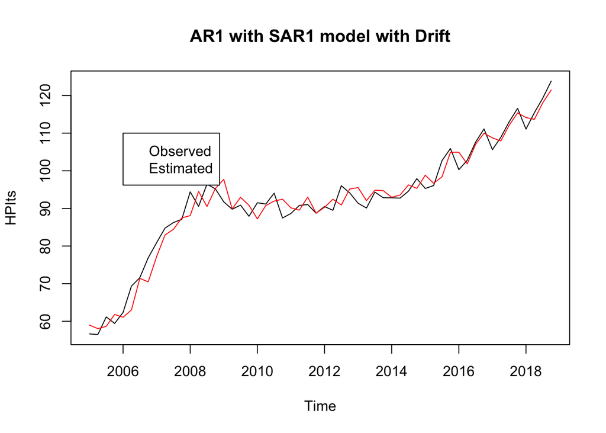

```r
#q=decompose(HPIts, type = "multiplicative", filter = NULL)
#plot(q)

#ARMA component
m1<-Arima(HPIts,order=c(1,0,0),seasonal = c(1,0,0), include.drift = TRUE)
plot(HPIts,main="AR1 with SAR1 model with Drift")
lines(m1$fitted,col='red')
legend(2006,110,legend=c("Observed","Estimated"),col=c("black","red"))
```

```r
Box.test(m1$residuals)
```

```
##
##  Box-Pierce test
##
## data:  m1$residuals
## X-squared = 0.87189, df = 1, p-value = 0.3504
```

The model includes both a seasonal AR-1 and a regular AR-1 component with a drift, which captures the linear component of the data, thereby satisfying the conditions for a model that includes a linear, seasonal, and cyclical component. The residuals satisfy the conditions of a white noise series, suggesting that the model is robust.

##### EU GDP

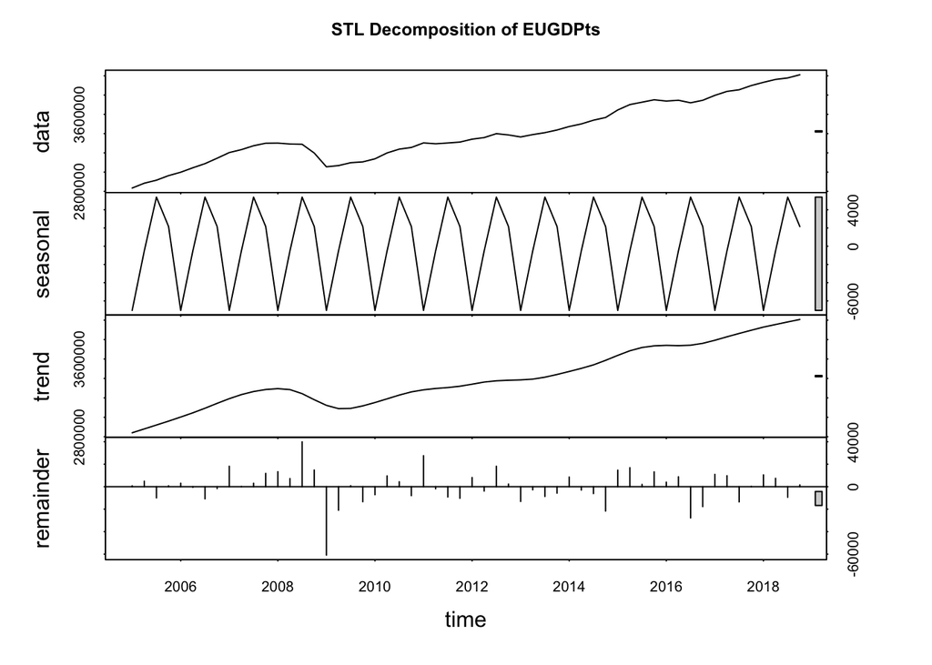

```r
stlEUGDP=stl(EUGDPts,s.window = "periodic")
plot(stlEUGDP,main="STL Decomposition of EUGDPts")
```

```r
mEU1 <- Arima(EUGDPts, order = c(1,0,0))
#alternative models
mEU2 <- Arima(EUGDPts, order = c(1,1,0))
mEU3 <- Arima(EUGDPts, order = c(1,1,0), seasonal = c(1,0,0))
#Look at model selection criteria
AIC(mEU1,mEU2,mEU3)
```

```
##      df      AIC
## mEU1  3 1359.036
## mEU2  2 1299.184
## mEU3  3 1300.255
```

```r
BIC(mEU1,mEU2,mEU3)
```

```
##      df      BIC
## mEU1  3 1365.112
## mEU2  2 1303.199
## mEU3  3 1306.277
```

AIC and BIC both agree that mEU2 is the best model. Hence, we propose an arima(1,1,0) model for EUGDP, we eliminate the seasonal component.

### Residual Analysis

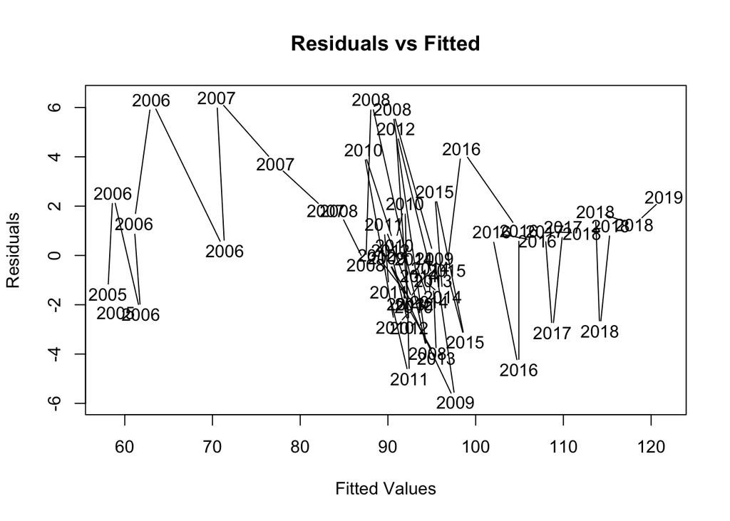

```r
  plot(m1$fitted,m1$residuals,main="Residuals vs Fitted",xlab="Fitted Values",ylab="Residuals",type="l")
```

Analysis shows qualitatively that most of the scattering away from zero tends to occur at smaller values of the HPI near 65-80 and the 90-100 range, stabilizing closer to zero at larger values.

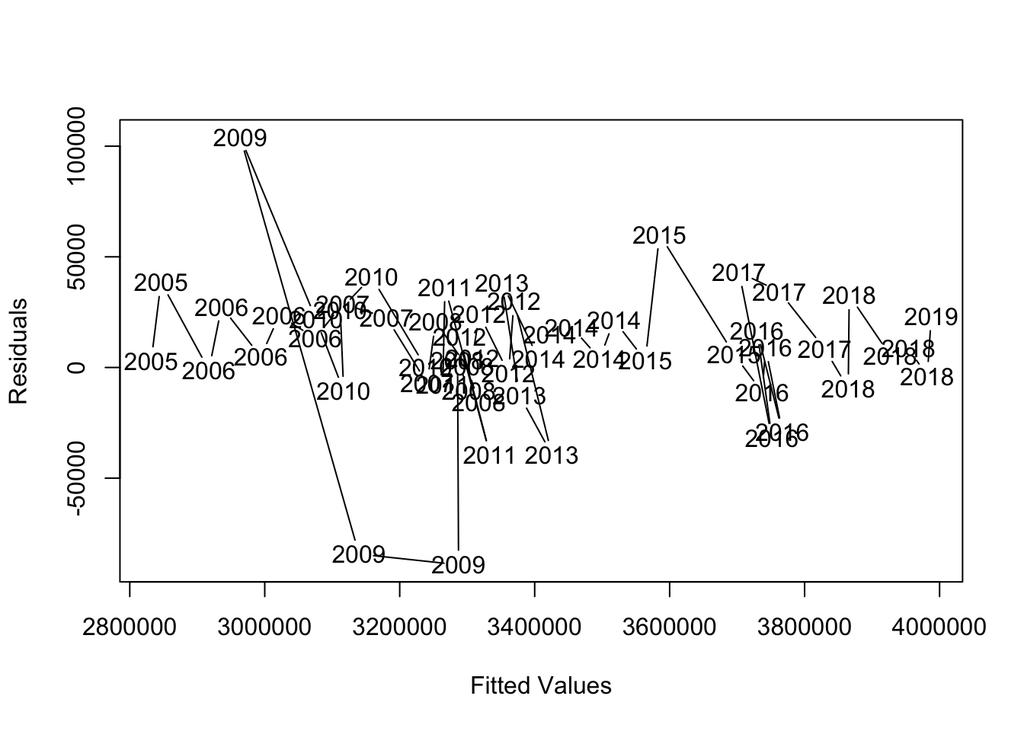

```r
EUresid = resid(mEU2)
plot(mEU2$fitted, EUresid, xlab = "Fitted Values", ylab = "Residuals")
```

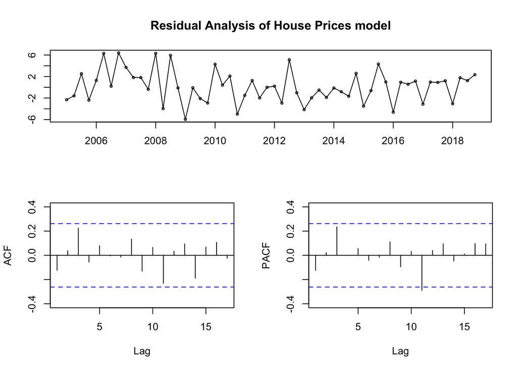

```r
tsdisplay(m1$residuals,main="Residual Analysis of House Prices model")
```

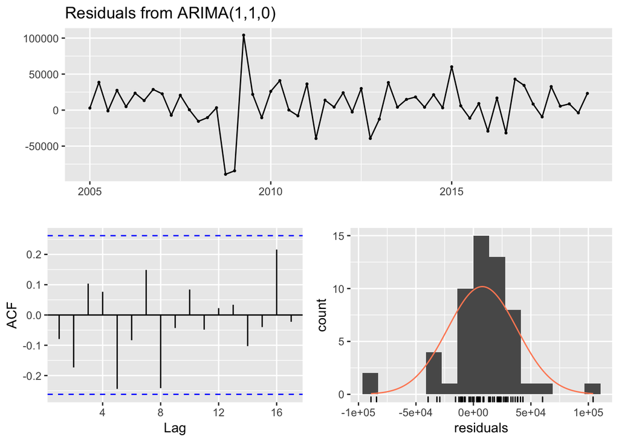

```
##
##  Ljung-Box test
##
## data:  Residuals from ARIMA(1,1,0)
## Q* = 12.859, df = 7, p-value = 0.07561
##
## Model df: 1.   Total lags used: 8
```

```r
checkresiduals(mEU2)
```

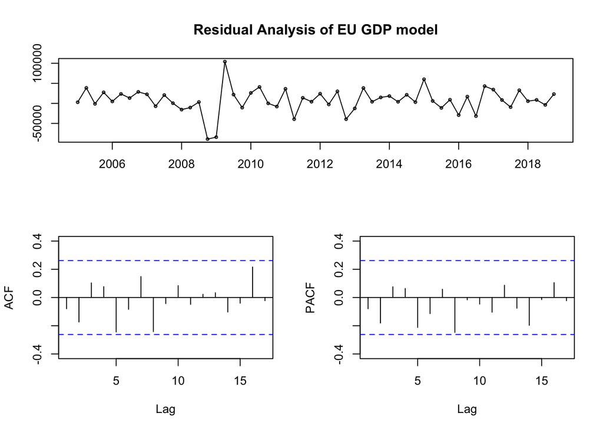

```r
tsdisplay(mEU2$residuals,main="Residual Analysis of EU GDP model")
```

##

The plot of the residuals against the fitted values show that they are mostly centered around 0 with a few outliers. Despite qualitiative asessment of residuals vs fitted values seeming to gravitate away from zero for some observations, the acf and pacf of the residuals demonstrate that the residuals resemble a white noise series, therefore suggesting that the model is robust enough to move forward with.

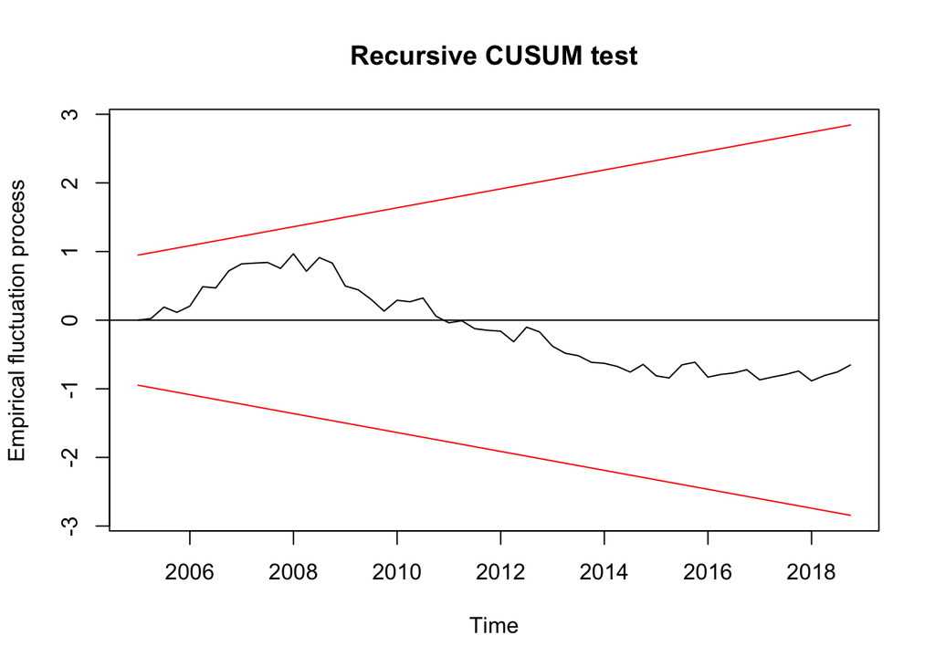

```r
plot(efp(m1$res~1, type = "Rec-CUSUM"))
```

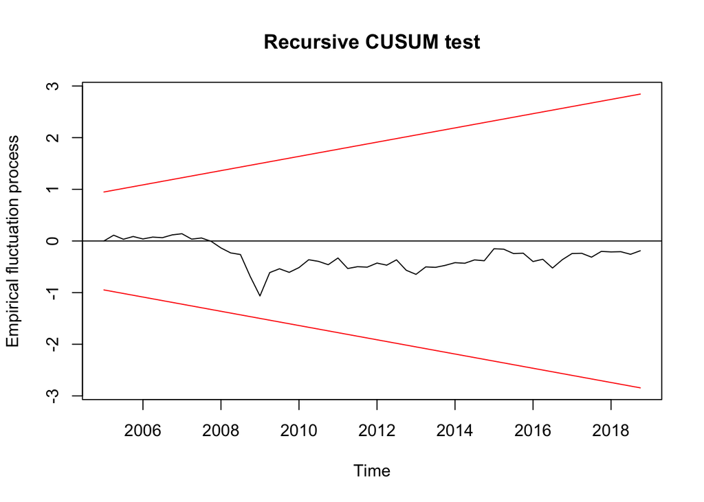

```r
plot(efp(mEU2$res~1, type = "Rec-CUSUM"))
```

##

Overall, the CUSUM test demonstrates the statistical significant of both models as well as theier stability; the recursive cumulative residuals stay within the bounds and don’t suggest any long-term trajectory that would create a parameter-breaking scenario. This suggests that our models handle the data well.

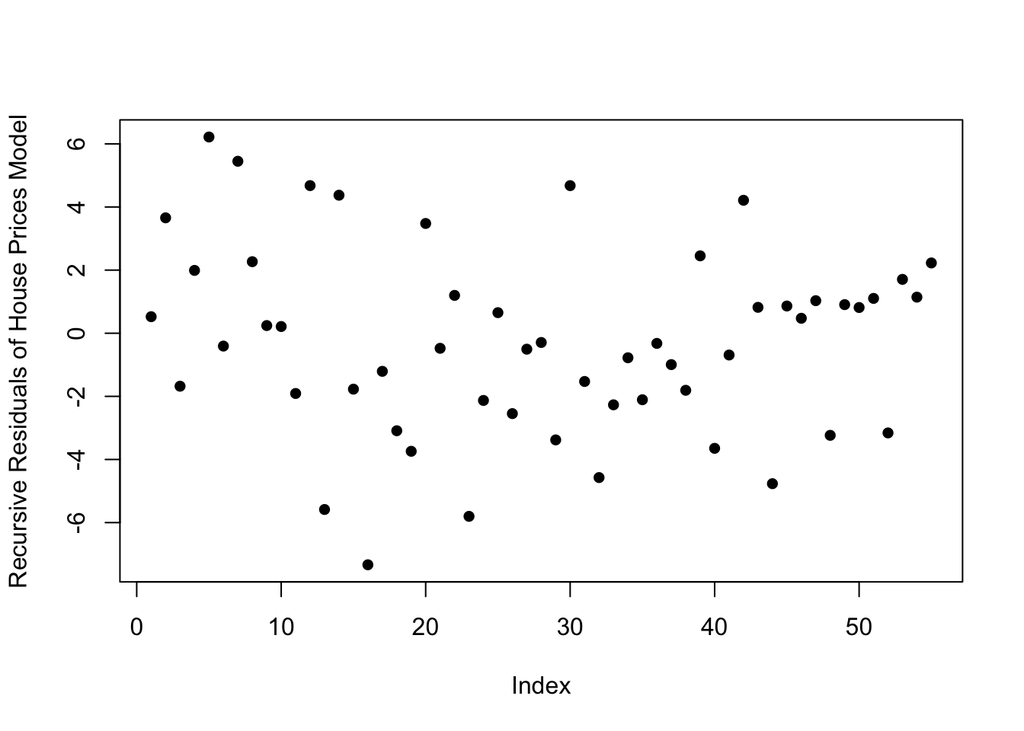

```r
y=recresid(m1$res~1)
plot(y, pch=16,ylab="Recursive Residuals of House Prices Model")
```

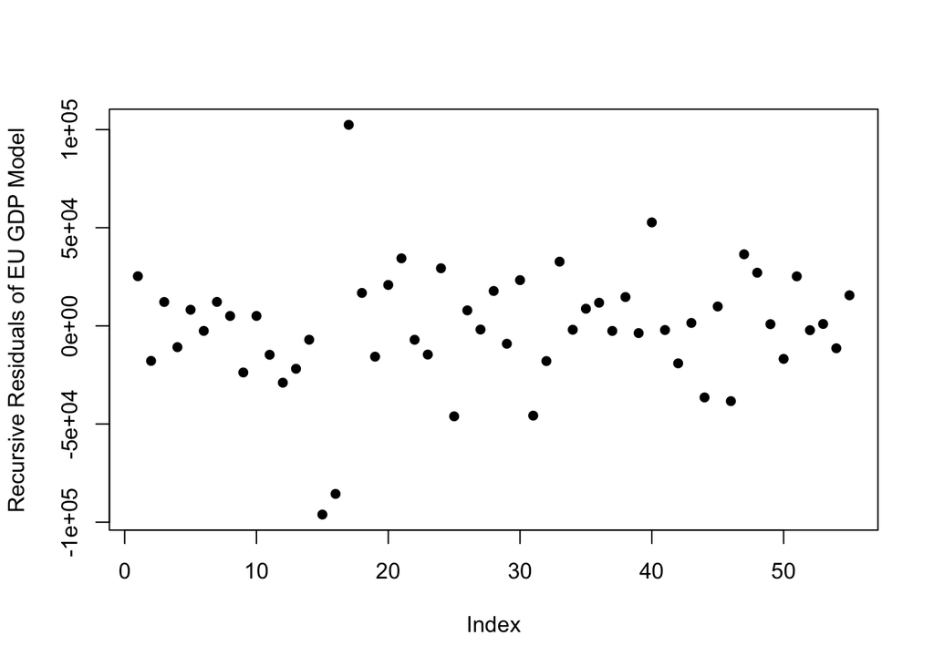

```r
w=recresid(mEU2$res~1)
plot(w, pch=16,ylab="Recursive Residuals of EU GDP Model")
```

Although the recursive residuals are scattered considerably around zero with significant spread, no pattern seems to exist that would suggest a breaking of any model parameters.

The residuals of EUGDP look to be randomly distributed about a mean of 0, however, there seems to be some outliers at an index of around 15. Nonetheless, as shown by the CUSUM plot above, this does not result in significant breaks in the model.

### Diagnostic Statistics

```r
summary(m1)
```

```
## Series: HPIts
## ARIMA(1,0,0)(1,0,0)[4] with drift
##
## Coefficients:
##          ar1    sar1  intercept   drift
##       0.8316  0.5087    61.8329  1.0444
## s.e.  0.0720  0.1217     6.9964  0.1981
##
## sigma^2 estimated as 9.208:  log likelihood=-141.01
## AIC=292.03   AICc=293.23   BIC=302.15
##
## Training set error measures:
##                     ME     RMSE      MAE       MPE     MAPE      MASE
## Training set 0.1488562 2.924062 2.306875 0.1524002 2.612236 0.4123384
##                    ACF1
## Training set -0.1247774
```

```r
summary(mEU2)
```

```
## Series: EUGDPts
## ARIMA(1,1,0)
##
## Coefficients:
##          ar1
##       0.6420
## s.e.  0.1033
##
## sigma^2 estimated as 996508812:  log likelihood=-647.59
## AIC=1299.18   AICc=1299.42   BIC=1303.2
##
## Training set error measures:
##                    ME    RMSE      MAE       MPE      MAPE      MASE
## Training set 7741.341 30998.7 22236.74 0.2292366 0.6675559 0.1921559
##                     ACF1
## Training set -0.07932757
```

All other salient diagnostics have been analyzed in the previous components of this project; the remaining salient components are the ME, Sigma^2 and log likelihood as the Arima function does not return significance values for any of the components. The model is overall significant with a small enough sigma squared, largely in line with the residuals behaving as a white noise series. The standard error for each of the components is also considerably small with the exception of the intercept term, which doesn’t factor significantly into the robustness of the model.

### 12-step ahead forecast

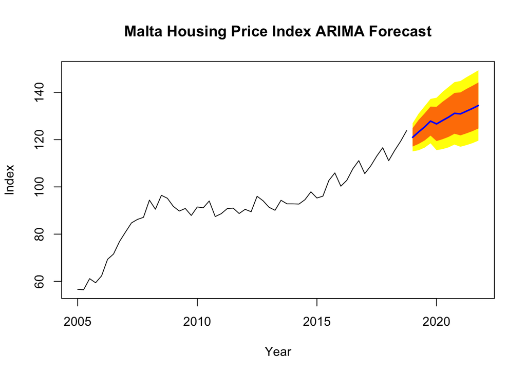

```r
plot(forecast((m1), h=12) ,shadecols="oldstyle", main="Malta Housing Price Index ARIMA Forecast",xlab="Year", ylab ="Index")
```

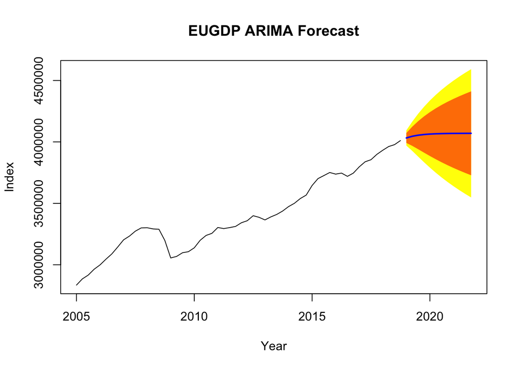

```r
plot(forecast((mEU2) , h=12) ,shadecols="oldstyle", main="EUGDP ARIMA Forecast",xlab="Year", ylab ="Index")
```

## VAR modeling, forecasting, and causality analysis

### VAR Model and plot discussion

```r
z=cbind(HPIts,EUGDPts)
VARm=data.frame(z)
VARselect(VARm, lag.max = 12)
```

```
## $selection
## AIC(n)  HQ(n)  SC(n) FPE(n)
##      9      6      1      7
##
## $criteria
##                   1            2            3            4            5
## AIC(n) 2.346747e+01 2.338754e+01 2.345203e+01 2.333815e+01 2.310266e+01
## HQ(n)  2.355770e+01 2.353792e+01 2.366255e+01 2.360883e+01 2.343349e+01
## SC(n)  2.371077e+01 2.379304e+01 2.401972e+01 2.406805e+01 2.399476e+01
## FPE(n) 1.555882e+10 1.438591e+10 1.539759e+10 1.382657e+10 1.103471e+10
##                   6            7            8            9           10
## AIC(n) 2.296333e+01 2.293048e+01 2.303441e+01 2.288572e+01 2.289016e+01
## HQ(n)  2.335431e+01 2.338161e+01 2.354569e+01 2.345715e+01 2.352175e+01
## SC(n)  2.401762e+01 2.414697e+01 2.441310e+01 2.442661e+01 2.459325e+01
## FPE(n) 9.741296e+09 9.622087e+09 1.097655e+10 9.812887e+09 1.033556e+10
##                  11           12
## AIC(n) 2.294696e+01 2.303170e+01
## HQ(n)  2.363870e+01 2.378359e+01
## SC(n)  2.481225e+01 2.505919e+01
## FPE(n) 1.162458e+10 1.366784e+10
```

```r
VAR.select(VARm, ic="aic", pmax = 1)
```

```
## $IC
##        aic
## 0 29.00831
## 1 23.10880
##
## $p
## [1] 1
```

```r
#VAR.select(VARm, ic="sc", pmax = 3)
VAR1=VAR(VARm,p=11)
VAR2=VAR(VARm,p=1)
summary(VAR1)
```

```
##
## VAR Estimation Results:
## =========================
## Endogenous variables: HPIts, EUGDPts
## Deterministic variables: const
## Sample size: 45
## Log Likelihood: -597.513
## Roots of the characteristic polynomial:
## 0.9929 0.9929 0.9879 0.9578 0.9536 0.9536 0.9479 0.9479 0.8978 0.8978 0.8841 0.8841 0.8822 0.8822 0.8797 0.8797 0.8793 0.8793 0.7789 0.7789 0.5058 0.1921
## Call:
## VAR(y = VARm, p = 11)
##
##
## Estimation results for equation HPIts:
## ======================================
## HPIts = HPIts.l1 + EUGDPts.l1 + HPIts.l2 + EUGDPts.l2 + HPIts.l3 + EUGDPts.l3 + HPIts.l4 + EUGDPts.l4 + HPIts.l5 + EUGDPts.l5 + HPIts.l6 + EUGDPts.l6 + HPIts.l7 + EUGDPts.l7 + HPIts.l8 + EUGDPts.l8 + HPIts.l9 + EUGDPts.l9 + HPIts.l10 + EUGDPts.l10 + HPIts.l11 + EUGDPts.l11 + const
##
##               Estimate Std. Error t value Pr(>|t|)
## HPIts.l1    -1.140e-01  2.037e-01  -0.560  0.58143
## EUGDPts.l1   4.274e-05  1.449e-05   2.949  0.00741 **
## HPIts.l2     9.474e-02  1.953e-01   0.485  0.63247
## EUGDPts.l2  -5.419e-06  2.687e-05  -0.202  0.84201
## HPIts.l3     3.840e-01  1.929e-01   1.991  0.05907 .
## EUGDPts.l3   3.062e-06  2.711e-05   0.113  0.91110
## HPIts.l4     7.613e-01  2.025e-01   3.760  0.00108 **
## EUGDPts.l4  -6.015e-06  2.651e-05  -0.227  0.82260
## HPIts.l5     3.154e-01  2.390e-01   1.320  0.20048
## EUGDPts.l5  -4.019e-05  2.476e-05  -1.623  0.11878
## HPIts.l6    -5.894e-02  2.067e-01  -0.285  0.77825
## EUGDPts.l6   4.696e-06  2.558e-05   0.184  0.85602
## HPIts.l7    -2.304e-01  1.886e-01  -1.222  0.23462
## EUGDPts.l7   1.937e-05  2.488e-05   0.779  0.44456
## HPIts.l8     2.114e-01  1.942e-01   1.088  0.28817
## EUGDPts.l8  -5.063e-06  2.507e-05  -0.202  0.84183
## HPIts.l9    -1.257e-01  1.975e-01  -0.636  0.53128
## EUGDPts.l9   1.582e-05  2.478e-05   0.638  0.52981
## HPIts.l10    4.976e-02  1.919e-01   0.259  0.79782
## EUGDPts.l10 -2.065e-05  2.589e-05  -0.798  0.43349
## HPIts.l11   -1.976e-01  1.694e-01  -1.167  0.25583
## EUGDPts.l11 -9.401e-06  1.827e-05  -0.514  0.61204
```

[output cut: 42 more lines]

```
## Residual standard error: 31850 on 22 degrees of freedom
## Multiple R-Squared: 0.9933,  Adjusted R-squared: 0.9867
## F-statistic: 149.3 on 22 and 22 DF,  p-value: < 2.2e-16
##
##
##
## Covariance matrix of residuals:
##            HPIts   EUGDPts
## HPIts      4.885 7.758e+03
## EUGDPts 7757.891 1.015e+09
##
## Correlation matrix of residuals:
##          HPIts EUGDPts
## HPIts   1.0000  0.1102
## EUGDPts 0.1102  1.0000
```

```r
summary(VAR2)
```

```
##
## VAR Estimation Results:
## =========================
## Endogenous variables: HPIts, EUGDPts
## Deterministic variables: const
## Sample size: 55
## Log Likelihood: -787.575
## Roots of the characteristic polynomial:
## 0.989 0.8497
## Call:
## VAR(y = VARm, p = 1)
##
##
## Estimation results for equation HPIts:
## ======================================
## HPIts = HPIts.l1 + EUGDPts.l1 + const
##
##              Estimate Std. Error t value Pr(>|t|)
## HPIts.l1    7.501e-01  6.484e-02  11.568 5.36e-16 ***
## EUGDPts.l1  1.128e-05  3.122e-06   3.613 0.000682 ***
## const      -1.412e+01  5.963e+00  -2.369 0.021604 *
## ---
## Signif. codes:  0 '***' 0.001 '**' 0.01 '*' 0.05 '.' 0.1 ' ' 1
##
##
## Residual standard error: 3.137 on 52 degrees of freedom
## Multiple R-Squared: 0.9535,  Adjusted R-squared: 0.9517
## F-statistic: 533.5 on 2 and 52 DF,  p-value: < 2.2e-16
##
##
## Estimation results for equation EUGDPts:
## ========================================
## EUGDPts = HPIts.l1 + EUGDPts.l1 + const
##
##              Estimate Std. Error t value Pr(>|t|)
## HPIts.l1   -2.110e+03  6.765e+02  -3.119  0.00296 **
## EUGDPts.l1  1.089e+00  3.257e-02  33.420  < 2e-16 ***
## const      -8.564e+04  6.222e+04  -1.376  0.17458
## ---
## Signif. codes:  0 '***' 0.001 '**' 0.01 '*' 0.05 '.' 0.1 ' ' 1
##
##
## Residual standard error: 32730 on 52 degrees of freedom
## Multiple R-Squared: 0.9887,  Adjusted R-squared: 0.9882
## F-statistic:  2269 on 2 and 52 DF,  p-value: < 2.2e-16
##
##
##
## Covariance matrix of residuals:
##            HPIts   EUGDPts
## HPIts      9.842 5.970e+03
## EUGDPts 5969.657 1.071e+09
##
## Correlation matrix of residuals:
##           HPIts EUGDPts
## HPIts   1.00000 0.05813
## EUGDPts 0.05813 1.00000
```

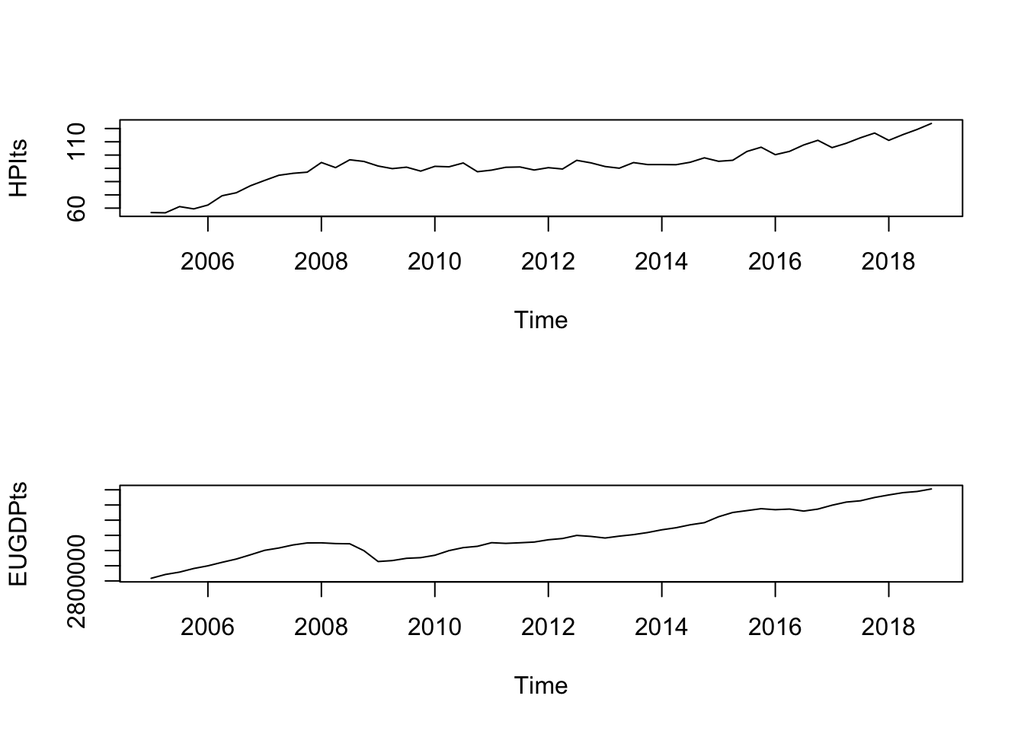

```r
#Look at both time series plots for a sanity check
par(mfrow=c(2,1))
plot(HPIts)
plot(EUGDPts)
```

```r
summary(VAR1)
```

```
##
## VAR Estimation Results:
## =========================
## Endogenous variables: HPIts, EUGDPts
## Deterministic variables: const
## Sample size: 45
## Log Likelihood: -597.513
## Roots of the characteristic polynomial:
## 0.9929 0.9929 0.9879 0.9578 0.9536 0.9536 0.9479 0.9479 0.8978 0.8978 0.8841 0.8841 0.8822 0.8822 0.8797 0.8797 0.8793 0.8793 0.7789 0.7789 0.5058 0.1921
## Call:
## VAR(y = VARm, p = 11)
##
##
## Estimation results for equation HPIts:
## ======================================
## HPIts = HPIts.l1 + EUGDPts.l1 + HPIts.l2 + EUGDPts.l2 + HPIts.l3 + EUGDPts.l3 + HPIts.l4 + EUGDPts.l4 + HPIts.l5 + EUGDPts.l5 + HPIts.l6 + EUGDPts.l6 + HPIts.l7 + EUGDPts.l7 + HPIts.l8 + EUGDPts.l8 + HPIts.l9 + EUGDPts.l9 + HPIts.l10 + EUGDPts.l10 + HPIts.l11 + EUGDPts.l11 + const
##
##               Estimate Std. Error t value Pr(>|t|)
## HPIts.l1    -1.140e-01  2.037e-01  -0.560  0.58143
## EUGDPts.l1   4.274e-05  1.449e-05   2.949  0.00741 **
## HPIts.l2     9.474e-02  1.953e-01   0.485  0.63247
## EUGDPts.l2  -5.419e-06  2.687e-05  -0.202  0.84201
## HPIts.l3     3.840e-01  1.929e-01   1.991  0.05907 .
## EUGDPts.l3   3.062e-06  2.711e-05   0.113  0.91110
## HPIts.l4     7.613e-01  2.025e-01   3.760  0.00108 **
## EUGDPts.l4  -6.015e-06  2.651e-05  -0.227  0.82260
## HPIts.l5     3.154e-01  2.390e-01   1.320  0.20048
## EUGDPts.l5  -4.019e-05  2.476e-05  -1.623  0.11878
## HPIts.l6    -5.894e-02  2.067e-01  -0.285  0.77825
## EUGDPts.l6   4.696e-06  2.558e-05   0.184  0.85602
## HPIts.l7    -2.304e-01  1.886e-01  -1.222  0.23462
## EUGDPts.l7   1.937e-05  2.488e-05   0.779  0.44456
## HPIts.l8     2.114e-01  1.942e-01   1.088  0.28817
## EUGDPts.l8  -5.063e-06  2.507e-05  -0.202  0.84183
## HPIts.l9    -1.257e-01  1.975e-01  -0.636  0.53128
## EUGDPts.l9   1.582e-05  2.478e-05   0.638  0.52981
## HPIts.l10    4.976e-02  1.919e-01   0.259  0.79782
## EUGDPts.l10 -2.065e-05  2.589e-05  -0.798  0.43349
## HPIts.l11   -1.976e-01  1.694e-01  -1.167  0.25583
## EUGDPts.l11 -9.401e-06  1.827e-05  -0.514  0.61204
```

[output cut: 42 more lines]

```
## Residual standard error: 31850 on 22 degrees of freedom
## Multiple R-Squared: 0.9933,  Adjusted R-squared: 0.9867
## F-statistic: 149.3 on 22 and 22 DF,  p-value: < 2.2e-16
##
##
##
## Covariance matrix of residuals:
##            HPIts   EUGDPts
## HPIts      4.885 7.758e+03
## EUGDPts 7757.891 1.015e+09
##
## Correlation matrix of residuals:
##          HPIts EUGDPts
## HPIts   1.0000  0.1102
## EUGDPts 0.1102  1.0000
```

```r
summary(VAR2)
```

```
##
## VAR Estimation Results:
## =========================
## Endogenous variables: HPIts, EUGDPts
## Deterministic variables: const
## Sample size: 55
## Log Likelihood: -787.575
## Roots of the characteristic polynomial:
## 0.989 0.8497
## Call:
## VAR(y = VARm, p = 1)
##
##
## Estimation results for equation HPIts:
## ======================================
## HPIts = HPIts.l1 + EUGDPts.l1 + const
##
##              Estimate Std. Error t value Pr(>|t|)
## HPIts.l1    7.501e-01  6.484e-02  11.568 5.36e-16 ***
## EUGDPts.l1  1.128e-05  3.122e-06   3.613 0.000682 ***
## const      -1.412e+01  5.963e+00  -2.369 0.021604 *
## ---
## Signif. codes:  0 '***' 0.001 '**' 0.01 '*' 0.05 '.' 0.1 ' ' 1
##
##
## Residual standard error: 3.137 on 52 degrees of freedom
## Multiple R-Squared: 0.9535,  Adjusted R-squared: 0.9517
## F-statistic: 533.5 on 2 and 52 DF,  p-value: < 2.2e-16
##
##
## Estimation results for equation EUGDPts:
## ========================================
## EUGDPts = HPIts.l1 + EUGDPts.l1 + const
##
##              Estimate Std. Error t value Pr(>|t|)
## HPIts.l1   -2.110e+03  6.765e+02  -3.119  0.00296 **
## EUGDPts.l1  1.089e+00  3.257e-02  33.420  < 2e-16 ***
## const      -8.564e+04  6.222e+04  -1.376  0.17458
## ---
## Signif. codes:  0 '***' 0.001 '**' 0.01 '*' 0.05 '.' 0.1 ' ' 1
##
##
## Residual standard error: 32730 on 52 degrees of freedom
## Multiple R-Squared: 0.9887,  Adjusted R-squared: 0.9882
## F-statistic:  2269 on 2 and 52 DF,  p-value: < 2.2e-16
##
##
##
## Covariance matrix of residuals:
##            HPIts   EUGDPts
## HPIts      9.842 5.970e+03
## EUGDPts 5969.657 1.071e+09
##
## Correlation matrix of residuals:
##           HPIts EUGDPts
## HPIts   1.00000 0.05813
## EUGDPts 0.05813 1.00000
```

Based on VAR select, AIC selects a model with lag of 9, whereas SC picks a model with only a lag of 1. Looking at the plot of both series, it is not clear which lag is more apparent.

### Impulse Response Interpretation

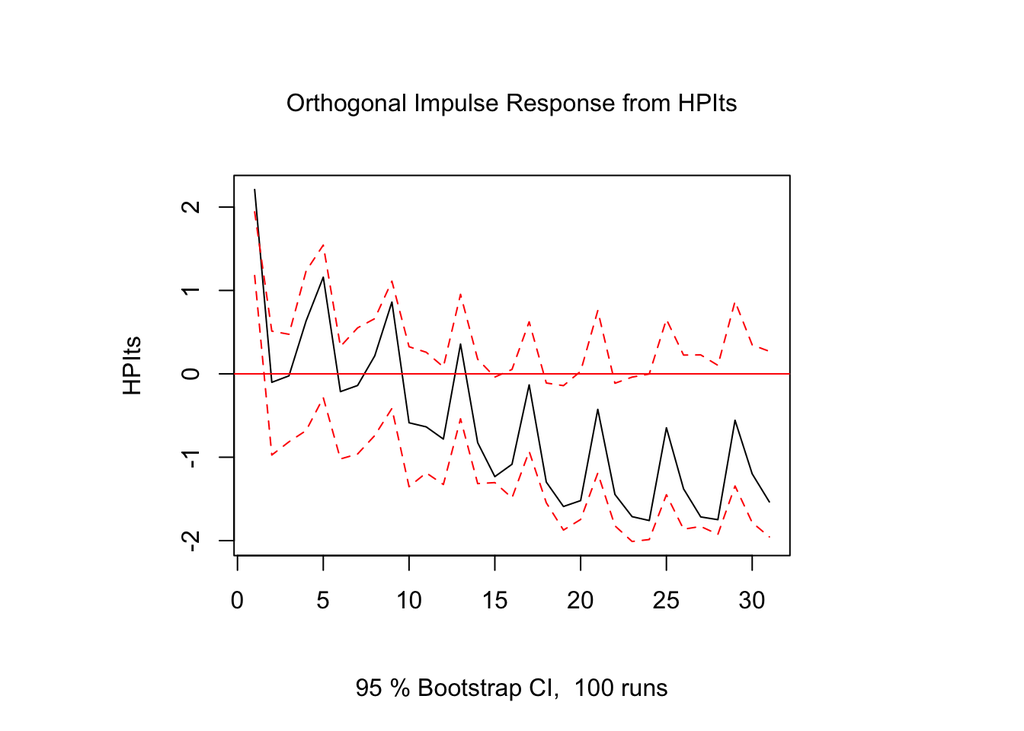

```r
plot(irf(VAR1, impulse = "HPIts", response = "HPIts", n.ahead=30))
```

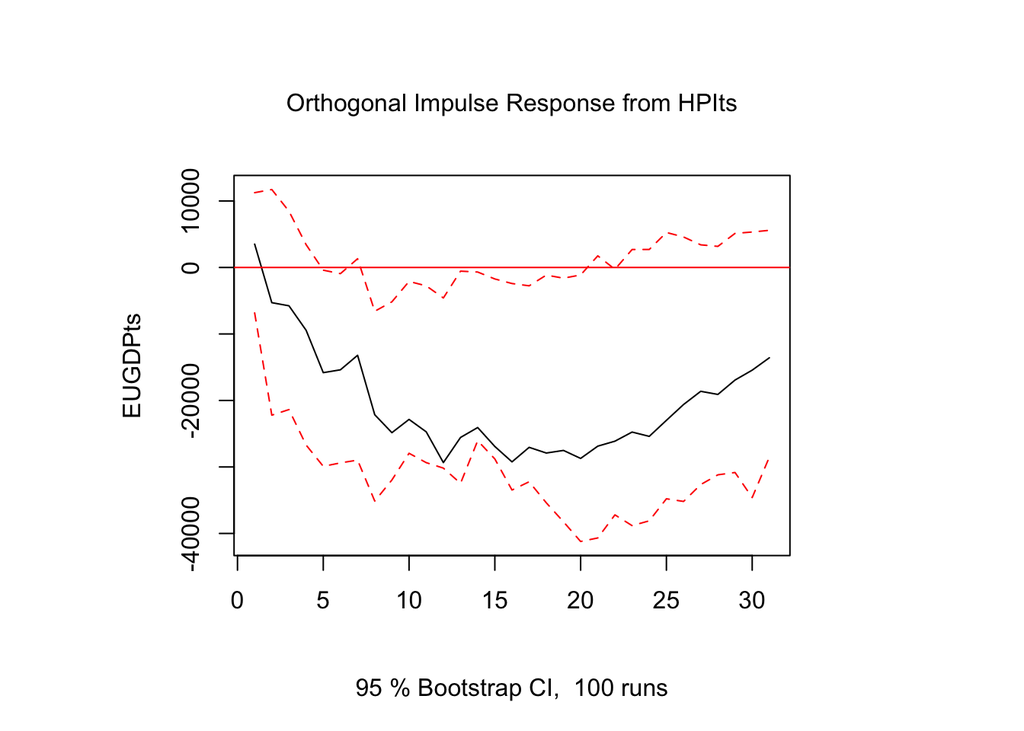

```r
plot(irf(VAR1, impulse = "HPIts", response = "EUGDPts", n.ahead=30))
```

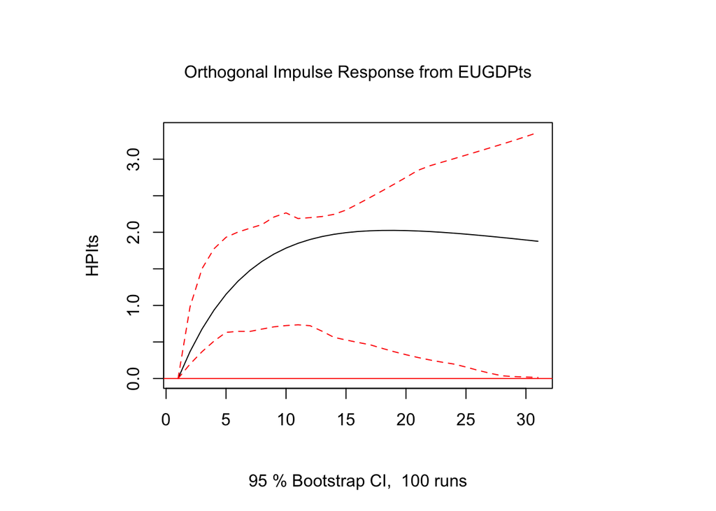

```r
plot(irf(VAR2, impulse = "EUGDPts", response = "HPIts", n.ahead=30))
```

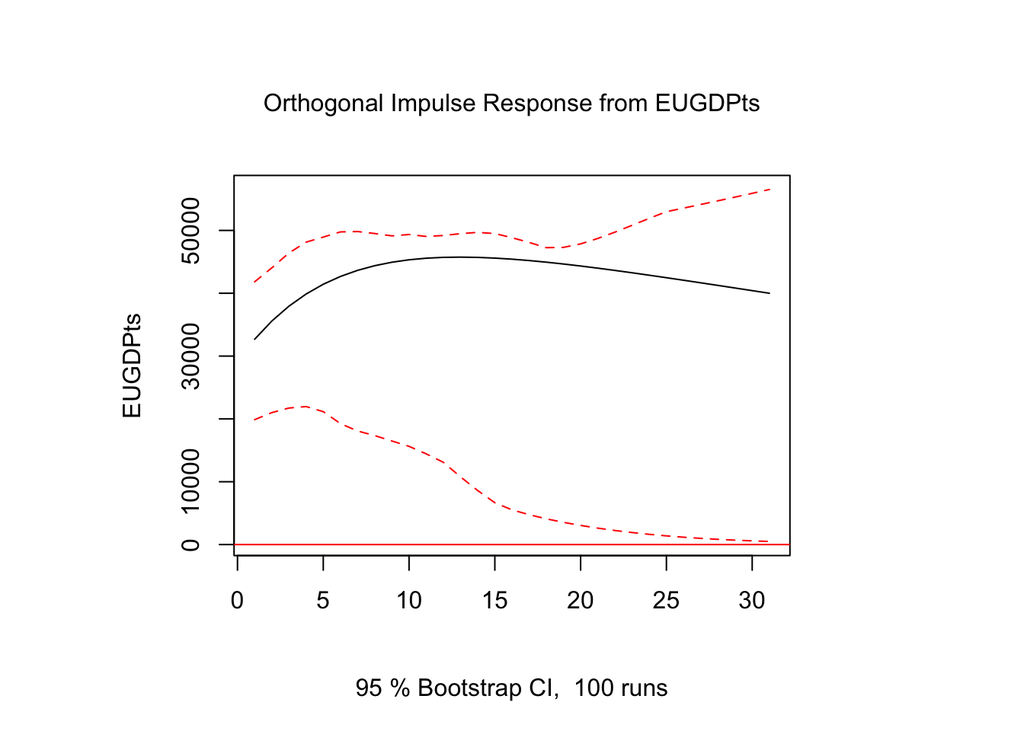

```r
plot(irf(VAR2, impulse = "EUGDPts", response = "EUGDPts", n.ahead=30))
```

The first plot shows the irf plot of shocks from HPIts on HPIts. There seems to be some seasonality in the shocks, with spikes occuring at regular intervals. The overall effect is stronly positive at the start, before slowly becoming negative.

The second plot shows the irf plot of shocks from HPIts on EUGDPts. The initial shock is small, before becoming strongly negative over time.

The third plot shows the irf plot of shocks from EUGDPts on HPIts. The intial shock is small, before increasing over time.

The fourth plot shows the irf plot of shocks from EUGDPts on EUGDPts. The initial shock is significant, but stays relatively constant.

### Granger Causality Analysis

```r
grangertest(HPIts ~ EUGDPts, order = 1)
```

```
## Granger causality test
##
## Model 1: HPIts ~ Lags(HPIts, 1:1) + Lags(EUGDPts, 1:1)
## Model 2: HPIts ~ Lags(HPIts, 1:1)
##   Res.Df Df      F    Pr(>F)
## 1     52
## 2     53 -1 13.055 0.0006817 ***
## ---
## Signif. codes:  0 '***' 0.001 '**' 0.01 '*' 0.05 '.' 0.1 ' ' 1
```

```r
grangertest(EUGDPts ~ HPIts, order = 1)
```

```
## Granger causality test
##
## Model 1: EUGDPts ~ Lags(EUGDPts, 1:1) + Lags(HPIts, 1:1)
## Model 2: EUGDPts ~ Lags(EUGDPts, 1:1)
##   Res.Df Df      F   Pr(>F)
## 1     52
## 2     53 -1 9.7268 0.002959 **
## ---
## Signif. codes:  0 '***' 0.001 '**' 0.01 '*' 0.05 '.' 0.1 ' ' 1
```

### 12-step ahead forecast, comparison with univariate models

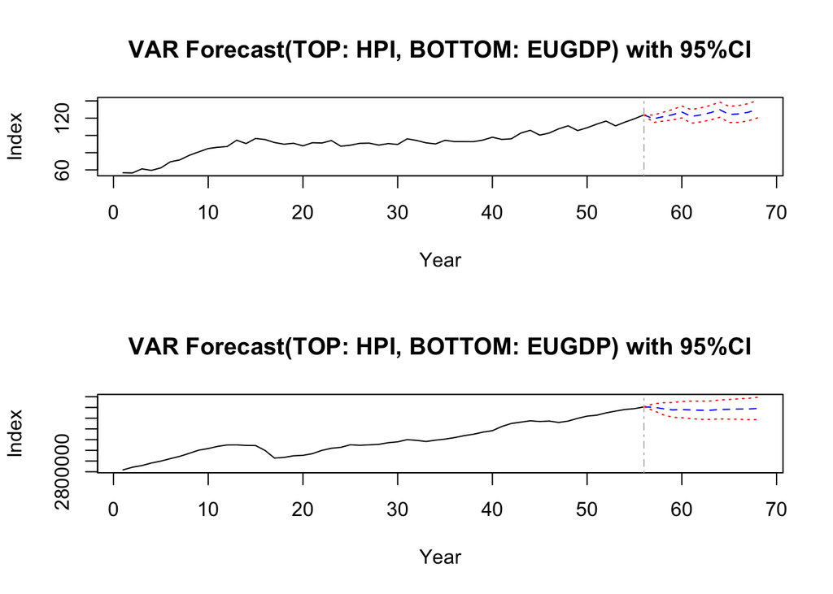

```r
#VAR forecasts
plot(predict(VAR1 , n.ahead=12, ci = c(0.95)), main="VAR Forecast(TOP: HPI, BOTTOM: EUGDP) with 95%CI",xlab="Year", ylab ="Index")
```

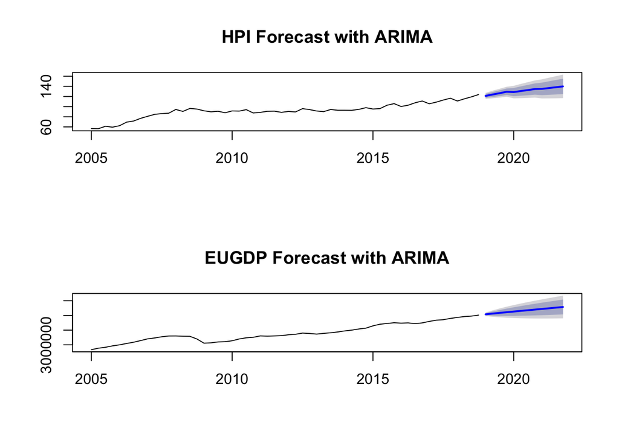

```r
#ARIMA forecasts
model.1 <- auto.arima(HPIts)
model.2 <- auto.arima(EUGDPts)
HPIts.fcast <- forecast(model.1, h=12)
EUGDP.fcast <- forecast(model.2, h=12)
par(mfrow = c(2,1))
plot(HPIts.fcast, main="HPI Forecast with ARIMA")
plot(EUGDP.fcast, main="EUGDP Forecast with ARIMA")
```

##

## Sources

- GDP data: https://fred.stlouisfed.org/series/CPMNACSCAB1GQEU28
- HPI data: https://sdw.ecb.europa.eu/quickview.do;jsessionid=636A712928C299F1FD6A01976FABDD51?SERIES_KEY=129.RPP.Q.MT.N.TD.00.4.00&start=01-01-2000&end=26-05-2019&submitOptions.x=0&submitOptions.y=0&trans=N